# Predict Bike Sharing Demand with AutoGluon Template

# Deleted Instruction steps to insure html opens in github view

## Step 2: Download the Kaggle dataset using the kaggle python library

### Install packages

```python
!pip install -U pip
!pip install -U setuptools wheel
!pip install -U "mxnet<2.0.0" bokeh==2.0.1
!pip install autogluon --no-cache-dir
# Without --no-cache-dir, smaller aws instances may have trouble installing
```

[output not shown]

[output cut: 91 more lines]

[output not shown]

### Setup Kaggle API Key

```python
# create the .kaggle directory and an empty kaggle.json file
!mkdir -p ~/.kaggle
!touch ~/.kaggle/kaggle.json
!chmod 600 ~/.kaggle/kaggle.json
```

```python
import os
# Get the full path for the .kaggle directory
kaggle_dir = os.path.expanduser("~/.kaggle")
kaggle_dir
```

```
'/home/sagemaker-user/.kaggle'
```

```python
# Fill in your user name and key from creating the kaggle account and API token file
import json
kaggle_username = ""
kaggle_key = ""

# Save API token the kaggle.json file
with open("/home/sagemaker-user/.kaggle/kaggle.json", "w") as f:
    f.write(json.dumps({"username": kaggle_username, "key": kaggle_key}))
```

### Download and explore dataset

### Go to the bike sharing demand competition and agree to the terms

```python
# Download the dataset, it will be in a .zip file so you'll need to unzip it as well.
!kaggle competitions download -c bike-sharing-demand
# If you already downloaded it you can use the -o command to overwrite the file
!unzip -o bike-sharing-demand.zip
```

```
Downloading bike-sharing-demand.zip to /home/sagemaker-user/udacity_nano_degree_project1/project
Archive:  bike-sharing-demand.zip
  inflating: sampleSubmission.csv
  inflating: test.csv
  inflating: train.csv
```

```python
import pandas as pd
from autogluon.tabular import TabularPredictor
```

```python
# Create the train dataset in pandas by reading the csv
# Set the parsing of the datetime column so you can use some of the `dt` features in pandas later
train = pd.read_csv('train.csv', parse_dates=["datetime"])
train.head()
```

|  | datetime | season | holiday | workingday | weather | temp | atemp | humidity | windspeed | casual | registered | count |
| --- | --- | --- | --- | --- | --- | --- | --- | --- | --- | --- | --- | --- |
| 0 | 2011-01-01 00:00:00 | 1 | 0 | 0 | 1 | 9.84 | 14.395 | 81 | 0.0 | 3 | 13 | 16 |
| 1 | 2011-01-01 01:00:00 | 1 | 0 | 0 | 1 | 9.02 | 13.635 | 80 | 0.0 | 8 | 32 | 40 |
| 2 | 2011-01-01 02:00:00 | 1 | 0 | 0 | 1 | 9.02 | 13.635 | 80 | 0.0 | 5 | 27 | 32 |
| 3 | 2011-01-01 03:00:00 | 1 | 0 | 0 | 1 | 9.84 | 14.395 | 75 | 0.0 | 3 | 10 | 13 |
| 4 | 2011-01-01 04:00:00 | 1 | 0 | 0 | 1 | 9.84 | 14.395 | 75 | 0.0 | 0 | 1 | 1 |

```python
# Simple output of the train dataset to view some of the min/max/varition of the dataset features.
train.describe()
```

|  | datetime | season | holiday | workingday | weather | temp | atemp | humidity | windspeed | casual | registered | count |
| --- | --- | --- | --- | --- | --- | --- | --- | --- | --- | --- | --- | --- |
| count | 10886 | 10886.000000 | 10886.000000 | 10886.000000 | 10886.000000 | 10886.00000 | 10886.000000 | 10886.000000 | 10886.000000 | 10886.000000 | 10886.000000 | 10886.000000 |
| mean | 2011-12-27 05:56:22.399411968 | 2.506614 | 0.028569 | 0.680875 | 1.418427 | 20.23086 | 23.655084 | 61.886460 | 12.799395 | 36.021955 | 155.552177 | 191.574132 |
| min | 2011-01-01 00:00:00 | 1.000000 | 0.000000 | 0.000000 | 1.000000 | 0.82000 | 0.760000 | 0.000000 | 0.000000 | 0.000000 | 0.000000 | 1.000000 |
| 25% | 2011-07-02 07:15:00 | 2.000000 | 0.000000 | 0.000000 | 1.000000 | 13.94000 | 16.665000 | 47.000000 | 7.001500 | 4.000000 | 36.000000 | 42.000000 |
| 50% | 2012-01-01 20:30:00 | 3.000000 | 0.000000 | 1.000000 | 1.000000 | 20.50000 | 24.240000 | 62.000000 | 12.998000 | 17.000000 | 118.000000 | 145.000000 |
| 75% | 2012-07-01 12:45:00 | 4.000000 | 0.000000 | 1.000000 | 2.000000 | 26.24000 | 31.060000 | 77.000000 | 16.997900 | 49.000000 | 222.000000 | 284.000000 |
| max | 2012-12-19 23:00:00 | 4.000000 | 1.000000 | 1.000000 | 4.000000 | 41.00000 | 45.455000 | 100.000000 | 56.996900 | 367.000000 | 886.000000 | 977.000000 |
| std | NaN | 1.116174 | 0.166599 | 0.466159 | 0.633839 | 7.79159 | 8.474601 | 19.245033 | 8.164537 | 49.960477 | 151.039033 | 181.144454 |

```python
# Create the test pandas dataframe in pandas by reading the csv, remember to parse the datetime!
test = pd.read_csv('test.csv', parse_dates=["datetime"])
test.head()
```

|  | datetime | season | holiday | workingday | weather | temp | atemp | humidity | windspeed |
| --- | --- | --- | --- | --- | --- | --- | --- | --- | --- |
| 0 | 2011-01-20 00:00:00 | 1 | 0 | 1 | 1 | 10.66 | 11.365 | 56 | 26.0027 |
| 1 | 2011-01-20 01:00:00 | 1 | 0 | 1 | 1 | 10.66 | 13.635 | 56 | 0.0000 |
| 2 | 2011-01-20 02:00:00 | 1 | 0 | 1 | 1 | 10.66 | 13.635 | 56 | 0.0000 |
| 3 | 2011-01-20 03:00:00 | 1 | 0 | 1 | 1 | 10.66 | 12.880 | 56 | 11.0014 |
| 4 | 2011-01-20 04:00:00 | 1 | 0 | 1 | 1 | 10.66 | 12.880 | 56 | 11.0014 |

```python
# Same thing as train and test dataset
submission = pd.read_csv('sampleSubmission.csv', parse_dates=["datetime"])
submission.head()
```

|  | datetime | count |
| --- | --- | --- |
| 0 | 2011-01-20 00:00:00 | 0 |
| 1 | 2011-01-20 01:00:00 | 0 |
| 2 | 2011-01-20 02:00:00 | 0 |
| 3 | 2011-01-20 03:00:00 | 0 |
| 4 | 2011-01-20 04:00:00 | 0 |

```python
import seaborn as sns
import matplotlib.pyplot as plt
```

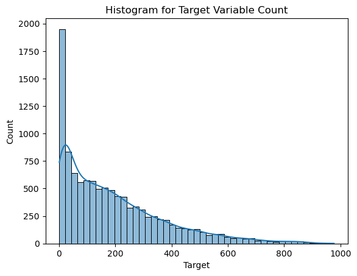

```python
fig=sns.histplot(train["count"],kde=True).get_figure()
plt.title("Histogram for Target Variable Count")
plt.xlabel("Target")
plt.show();
fig.savefig('Histogram.png')
```

## Step 3: Train a model using AutoGluon’s Tabular Prediction

Requirements:

- We are prediting `count`, so it is the label we are setting.
- Ignore `casual` and `registered` columns as they are also not present in the test dataset.
- Use the `root_mean_squared_error` as the metric to use for evaluation.
- Set a time limit of 10 minutes (600 seconds).
- Use the preset `best_quality` to focus on creating the best model.

```python
vars=list(test.columns)+['count']
predictor = TabularPredictor(label='count',eval_metric='root_mean_squared_error').fit(train_data=train[vars],time_limit=600,presets="best_quality")
```

[output not shown]

[output cut: 43 more lines]

[output not shown]

```
(_ray_fit pid=615) [1000]	valid_set's rmse: 129.692
```

[output not shown]

```
(_ray_fit pid=716) [1000]	valid_set's rmse: 132.725 [repeated 5x across cluster]
```

[output not shown]

```
(_ray_fit pid=752) [3000]	valid_set's rmse: 126.147 [repeated 3x across cluster]
(_ray_fit pid=752) [7000]	valid_set's rmse: 125.4 [repeated 7x across cluster]
(_ray_fit pid=787) [8000]	valid_set's rmse: 132.379 [repeated 7x across cluster]
```

[output not shown]

```
(_ray_fit pid=826) [1000]	valid_set's rmse: 137.712 [repeated 2x across cluster]
```

[output not shown]

```
(_ray_fit pid=872) [1000]	valid_set's rmse: 139.958 [repeated 4x across cluster]
(_ray_fit pid=872) [5000]	valid_set's rmse: 137.961 [repeated 8x across cluster]
```

[output not shown]

```
(_ray_fit pid=910) [1000]	valid_set's rmse: 129.274
(_ray_fit pid=911) [1000]	valid_set's rmse: 129.285
```

[output not shown]

```
(_ray_fit pid=978) [1000]	valid_set's rmse: 135.098
```

[output not shown]

```
(_ray_fit pid=1044) [1000]	valid_set's rmse: 124.896
```

[output not shown]

```
(_ray_fit pid=1115) [1000]	valid_set's rmse: 134.479 [repeated 2x across cluster]
```

[output not shown]

```
(_ray_fit pid=1192) [1000]	valid_set's rmse: 69.5159 [repeated 2x across cluster]
```

[output not shown]

```
(_ray_fit pid=1260) [1000]	valid_set's rmse: 78.3544 [repeated 2x across cluster]
```

[output not shown]

```
(_ray_fit pid=1330) [1000]	valid_set's rmse: 75.7703 [repeated 3x across cluster]
```

[output not shown]

```
(_ray_fit pid=1397) [1000]	valid_set's rmse: 71.8442 [repeated 2x across cluster]
```

[output not shown]

[output cut: 101 more lines]

```
	Fitting 8 child models (S1F1 - S1F8) | Fitting with ParallelLocalFoldFittingStrategy (2 workers, per: cpus=1, gpus=0, memory=0.79%)
	-54.9459	 = Validation score   (-root_mean_squared_error)
	26.43s	 = Training   runtime
	0.35s	 = Validation runtime
Fitting model: RandomForestMSE_BAG_L2 ... Training model for up to 19.82s of the 19.77s of remaining time.
	-53.3956	 = Validation score   (-root_mean_squared_error)
	44.36s	 = Training   runtime
	0.91s	 = Validation runtime
Fitting model: WeightedEnsemble_L3 ... Training model for up to 360.0s of the -26.6s of remaining time.
	Ensemble Weights: {'RandomForestMSE_BAG_L2': 0.706, 'LightGBM_BAG_L2': 0.235, 'LightGBMXT_BAG_L2': 0.059}
	-53.0398	 = Validation score   (-root_mean_squared_error)
	0.04s	 = Training   runtime
	0.0s	 = Validation runtime
AutoGluon training complete, total runtime = 459.65s ... Best model: WeightedEnsemble_L3 | Estimated inference throughput: 95.8 rows/s (1361 batch size)
TabularPredictor saved. To load, use: predictor = TabularPredictor.load("AutogluonModels/ag-20241225_044101")
```

### Review AutoGluon's training run with ranking of models that did the best.

```python
predictor.fit_summary()
```

```
*** Summary of fit() ***
Estimated performance of each model:
                     model   score_val              eval_metric  pred_time_val    fit_time  pred_time_val_marginal  fit_time_marginal  stack_level  can_infer  fit_order
0      WeightedEnsemble_L3  -53.039831  root_mean_squared_error      16.194508  425.412875                0.000805           0.043534            3       True         13
1   RandomForestMSE_BAG_L2  -53.395641  root_mean_squared_error      11.463237  337.438214                0.906069          44.359857            2       True         12
2          LightGBM_BAG_L2  -54.945855  root_mean_squared_error      10.903759  319.504654                0.346591          26.426296            2       True         11
3        LightGBMXT_BAG_L2  -60.090674  root_mean_squared_error      14.941042  354.583188                4.383874          61.504831            2       True         10
4    KNeighborsDist_BAG_L1  -84.125061  root_mean_squared_error       0.055211    0.033345                0.055211           0.033345            1       True          2
5      WeightedEnsemble_L2  -84.125061  root_mean_squared_error       0.056143    0.082106                0.000932           0.048761            2       True          9
6    KNeighborsUnif_BAG_L1 -101.546199  root_mean_squared_error       0.045692    0.050586                0.045692           0.050586            1       True          1
7   RandomForestMSE_BAG_L1 -116.548359  root_mean_squared_error       0.585522   13.567520                0.585522          13.567520            1       True          5
8     ExtraTreesMSE_BAG_L1 -124.600676  root_mean_squared_error       0.673943    7.565996                0.673943           7.565996            1       True          7
9          CatBoost_BAG_L1 -130.681677  root_mean_squared_error       0.109200  144.659867                0.109200         144.659867            1       True          6
10         LightGBM_BAG_L1 -131.054162  root_mean_squared_error       1.471591   25.322538                1.471591          25.322538            1       True          4
11       LightGBMXT_BAG_L1 -131.460909  root_mean_squared_error       7.245305   56.302661                7.245305          56.302661            1       True          3
12  NeuralNetFastAI_BAG_L1 -141.593672  root_mean_squared_error       0.370704   45.575845                0.370704          45.575845            1       True          8
Number of models trained: 13
Types of models trained:
{'StackerEnsembleModel_XT', 'StackerEnsembleModel_CatBoost', 'StackerEnsembleModel_LGB', 'StackerEnsembleModel_NNFastAiTabular', 'StackerEnsembleModel_KNN', 'WeightedEnsembleModel', 'StackerEnsembleModel_RF'}
Bagging used: True  (with 8 folds)
Multi-layer stack-ensembling used: True  (with 3 levels)
Feature Metadata (Processed):
(raw dtype, special dtypes):
('float', [])                : 3 | ['temp', 'atemp', 'windspeed']
('int', [])                  : 3 | ['season', 'weather', 'humidity']
('int', ['bool'])            : 2 | ['holiday', 'workingday']
('int', ['datetime_as_int']) : 5 | ['datetime', 'datetime.year', 'datetime.month', 'datetime.day', 'datetime.dayofweek']
*** End of fit() summary ***
```

[output not shown]

[output cut: 114 more lines]

```

     stack_level  can_infer  fit_order
 0             3       True         13
 1             2       True         12
 2             2       True         11
 3             2       True         10
 4             1       True          2
 5             2       True          9
 6             1       True          1
 7             1       True          5
 8             1       True          7
 9             1       True          6
 10            1       True          4
 11            1       True          3
 12            1       True          8  }
```

```python
vars1=['datetime', 'season', 'holiday', 'workingday', 'weather', 'temp',
       'atemp', 'humidity', 'windspeed', 'count']
```

### Create predictions from test dataset

```python
predictions = predictor.predict(test)
predictions.head()
```

```
0    22.974953
1    42.638565
2    46.046959
3    48.314030
4    50.782921
Name: count, dtype: float32
```

```python
# Get the name of the best model
best_model = predictor.get_model_best()
print(f"Best model: {best_model}")
```

```
Best model: WeightedEnsemble_L3
```

#### NOTE: Kaggle will reject the submission if we don't set everything to be > 0.

```python
# Describe the `predictions` series to see if there are any negative values
predictions.describe()
```

```
count    6493.000000
mean      100.638214
std        89.971222
min         2.970276
25%        19.965357
50%        64.002739
75%       167.353775
max       365.376038
Name: count, dtype: float64
```

```python
# How many negative values do we have?
sum((predictions < 0).astype("int"))
```

```
0
```

```python
# Set them to zero
predictions = predictions.apply(lambda x: max(0, x))
```

### Set predictions to submission dataframe, save, and submit

```python
submission["count"] = predictions
submission.to_csv("submission.csv", index=False)
```

```python
!kaggle competitions submit -c bike-sharing-demand -f submission.csv -m "first raw submission 1.0"
```

```
Successfully submitted to Bike Sharing Demand
```

#### View submission via the command line or in the web browser under the competition's page - `My Submissions`

```python
!kaggle competitions submissions -c bike-sharing-demand | tail -n+1 | head -n 3
```

```
fileName                     date                 description                        status    publicScore  privateScore
---------------------------  -------------------  ---------------------------------  --------  -----------  ------------
submission.csv               2024-12-25 05:04:27  first raw submission 1.0           complete  1.80091      1.80091
```

#### Initial score of `1.80091`

## Step 4: Exploratory Data Analysis and Creating an additional feature

- Any additional feature will do, but a great suggestion would be to separate out the datetime into hour, day, or month parts.

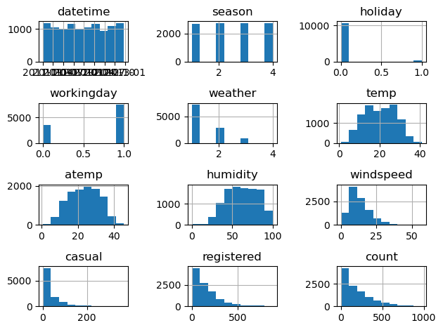

```python
# Create a histogram of all features to show the distribution of each one relative to the data. This is part of the exploritory data analysis
import matplotlib.pyplot as plt
train.hist()
plt.tight_layout()
plt.show();
```

```python
# create a new feature
train['demand_hour'] = train['datetime'].dt.hour
test['demand_hour'] = test['datetime'].dt.hour
```

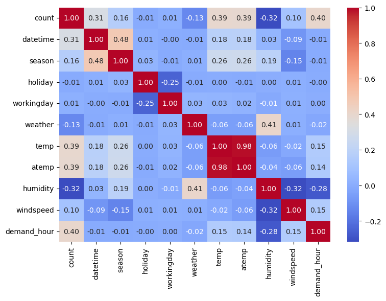

```python
cols=['count','datetime', 'season', 'holiday', 'workingday', 'weather', 'temp','atemp', 'humidity', 'windspeed','demand_hour']
plt.figure(figsize=(8, 6))
fig=sns.heatmap(train[cols].corr(),annot=True, fmt=".2f", cmap="coolwarm").get_figure()
plt.tight_layout()
plt.show();
fig.savefig('Correlation_Matrix.png')
```

## Make category types for these so models know they are not just numbers

- AutoGluon originally sees these as ints, but in reality they are int representations of a category.
- Setting the dtype to category will classify these as categories in AutoGluon.

```python
train["season"] = train["season"].astype("category")
train["weather"] = train["weather"].astype("category")
test["season"] = test["season"].astype("category")
test["weather"] = test["weather"].astype("category")
```

```python
# View are new feature
train.head()
```

|  | datetime | season | holiday | workingday | weather | temp | atemp | humidity | windspeed | casual | registered | count | demand_hour |
| --- | --- | --- | --- | --- | --- | --- | --- | --- | --- | --- | --- | --- | --- |
| 0 | 2011-01-01 00:00:00 | 1 | 0 | 0 | 1 | 9.84 | 14.395 | 81 | 0.0 | 3 | 13 | 16 | 0 |
| 1 | 2011-01-01 01:00:00 | 1 | 0 | 0 | 1 | 9.02 | 13.635 | 80 | 0.0 | 8 | 32 | 40 | 1 |
| 2 | 2011-01-01 02:00:00 | 1 | 0 | 0 | 1 | 9.02 | 13.635 | 80 | 0.0 | 5 | 27 | 32 | 2 |
| 3 | 2011-01-01 03:00:00 | 1 | 0 | 0 | 1 | 9.84 | 14.395 | 75 | 0.0 | 3 | 10 | 13 | 3 |
| 4 | 2011-01-01 04:00:00 | 1 | 0 | 0 | 1 | 9.84 | 14.395 | 75 | 0.0 | 0 | 1 | 1 | 4 |

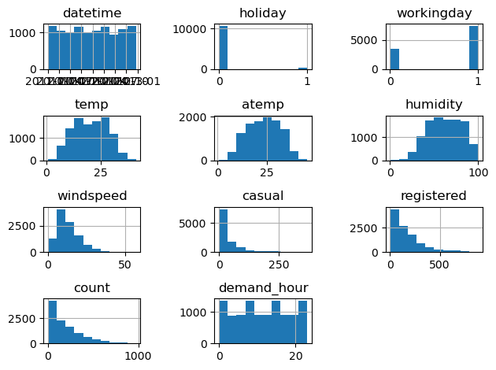

```python
# View histogram of all features again now with the hour feature
train.hist()
plt.tight_layout()
plt.show();
```

## Step 5: Rerun the model with the same settings as before, just with more features

```python
vars=list(test.columns)+['count']
```

```python
import gc
```

```python
gc.collect()
```

```
0
```

```python
predictor_new_features =  TabularPredictor(label='count',eval_metric='root_mean_squared_error').fit(
    train_data=train[vars],
    time_limit=600,
    presets="best_quality",
   # num_bag_folds= 10,
   #num_stack_levels=4
)
```

```
No path specified. Models will be saved in: "AutogluonModels/ag-20241225_070525"
Verbosity: 2 (Standard Logging)
=================== System Info ===================
AutoGluon Version:  1.1.1
Python Version:     3.11.10
Operating System:   Linux
Platform Machine:   x86_64
Platform Version:   #1 SMP Wed Oct 23 17:17:00 UTC 2024
CPU Count:          2
Memory Avail:       1.36 GB / 3.76 GB (36.1%)
Disk Space Avail:   2.75 GB / 4.99 GB (55.2%)
	WARNING: Available disk space is low and there is a risk that AutoGluon will run out of disk during fit, causing an exception.
	We recommend a minimum available disk space of 10 GB, and large datasets may require more.
===================================================
Presets specified: ['best_quality']
Setting dynamic_stacking from 'auto' to True. Reason: Enable dynamic_stacking when use_bag_holdout is disabled. (use_bag_holdout=False)
Stack configuration (auto_stack=True): num_stack_levels=1, num_bag_folds=8, num_bag_sets=1
DyStack is enabled (dynamic_stacking=True). AutoGluon will try to determine whether the input data is affected by stacked overfitting and enable or disable stacking as a consequence.
	This is used to identify the optimal `num_stack_levels` value. Copies of AutoGluon will be fit on subsets of the data. Then holdout validation data is used to detect stacked overfitting.
	Running DyStack for up to 150s of the 600s of remaining time (25%).
		Context path: "AutogluonModels/ag-20241225_070525/ds_sub_fit/sub_fit_ho"
Leaderboard on holdout data (DyStack):
                   model  score_holdout   score_val              eval_metric  pred_time_test  pred_time_val    fit_time  pred_time_test_marginal  pred_time_val_marginal  fit_time_marginal  stack_level  can_infer  fit_order
0    WeightedEnsemble_L3     -34.075067  -35.244748  root_mean_squared_error       26.166732      15.366807  156.248546                 0.002267                0.000793           0.050068            3       True          5
1    WeightedEnsemble_L2     -34.075067  -35.244748  root_mean_squared_error       26.167493      15.370736  156.278308                 0.003028                0.004723           0.079831            2       True          4
2      LightGBMXT_BAG_L1     -34.130379  -35.316584  root_mean_squared_error       26.063777      15.293417  156.177651                26.063777               15.293417         156.177651            1       True          3
3  KNeighborsDist_BAG_L1     -92.031272  -89.946854  root_mean_squared_error        0.100688       0.072596    0.020827                 0.100688                0.072596           0.020827            1       True          2
4  KNeighborsUnif_BAG_L1    -109.161488 -107.445008  root_mean_squared_error        0.016296       0.050077    0.018454                 0.016296                0.050077           0.018454            1       True          1
	1	 = Optimal   num_stack_levels (Stacked Overfitting Occurred: False)
	447s	 = DyStack   runtime |	153s	 = Remaining runtime
Starting main fit with num_stack_levels=1.
	For future fit calls on this dataset, you can skip DyStack to save time: `predictor.fit(..., dynamic_stacking=False, num_stack_levels=1)`
Beginning AutoGluon training ... Time limit = 153s
AutoGluon will save models to "AutogluonModels/ag-20241225_070525"
Train Data Rows:    10886
Train Data Columns: 10
Label Column:       count
Problem Type:       regression
Preprocessing data ...
Using Feature Generators to preprocess the data ...
```

[output cut: 61 more lines]

```
	148.86s	 = Training   runtime
	16.99s	 = Validation runtime
Fitting model: WeightedEnsemble_L2 ... Training model for up to 152.61s of the -161.18s of remaining time.
	Ensemble Weights: {'LightGBMXT_BAG_L1': 0.96, 'KNeighborsDist_BAG_L1': 0.04}
	-34.3426	 = Validation score   (-root_mean_squared_error)
	0.02s	 = Training   runtime
	0.0s	 = Validation runtime
Fitting 106 L2 models ...
Fitting model: WeightedEnsemble_L3 ... Training model for up to 152.61s of the -161.49s of remaining time.
	Ensemble Weights: {'LightGBMXT_BAG_L1': 0.96, 'KNeighborsDist_BAG_L1': 0.04}
	-34.3426	 = Validation score   (-root_mean_squared_error)
	0.03s	 = Training   runtime
	0.0s	 = Validation runtime
AutoGluon training complete, total runtime = 314.32s ... Best model: WeightedEnsemble_L2 | Estimated inference throughput: 80.0 rows/s (1361 batch size)
TabularPredictor saved. To load, use: predictor = TabularPredictor.load("AutogluonModels/ag-20241225_070525")
```

```python
predictor_new_features.fit_summary()
```

```
*** Summary of fit() ***
Estimated performance of each model:
                   model   score_val              eval_metric  pred_time_val    fit_time  pred_time_val_marginal  fit_time_marginal  stack_level  can_infer  fit_order
0    WeightedEnsemble_L2  -34.342648  root_mean_squared_error      17.075023  148.926526                0.000579           0.021269            2       True          4
1    WeightedEnsemble_L3  -34.342648  root_mean_squared_error      17.075651  148.933135                0.001207           0.027878            3       True          5
2      LightGBMXT_BAG_L1  -34.457274  root_mean_squared_error      16.991913  148.856911               16.991913         148.856911            1       True          3
3  KNeighborsDist_BAG_L1  -84.125061  root_mean_squared_error       0.082531    0.048346                0.082531           0.048346            1       True          2
4  KNeighborsUnif_BAG_L1 -101.546199  root_mean_squared_error       0.122361    0.053534                0.122361           0.053534            1       True          1
Number of models trained: 5
Types of models trained:
{'StackerEnsembleModel_LGB', 'WeightedEnsembleModel', 'StackerEnsembleModel_KNN'}
Bagging used: True  (with 8 folds)
Multi-layer stack-ensembling used: True  (with 3 levels)
Feature Metadata (Processed):
(raw dtype, special dtypes):
('category', [])             : 2 | ['season', 'weather']
('float', [])                : 3 | ['temp', 'atemp', 'windspeed']
('int', [])                  : 2 | ['humidity', 'demand_hour']
('int', ['bool'])            : 2 | ['holiday', 'workingday']
('int', ['datetime_as_int']) : 5 | ['datetime', 'datetime.year', 'datetime.month', 'datetime.day', 'datetime.dayofweek']
*** End of fit() summary ***
```

[output not shown]

[output cut: 15 more lines]

```
 4  KNeighborsUnif_BAG_L1 -101.546199  root_mean_squared_error       0.122361

      fit_time  pred_time_val_marginal  fit_time_marginal  stack_level  \
 0  148.926526                0.000579           0.021269            2
 1  148.933135                0.001207           0.027878            3
 2  148.856911               16.991913         148.856911            1
 3    0.048346                0.082531           0.048346            1
 4    0.053534                0.122361           0.053534            1

    can_infer  fit_order
 0       True          4
 1       True          5
 2       True          3
 3       True          2
 4       True          1  }
```

```python
# Remember to set all negative values to zero
predictions_1 = predictor_new_features.predict(test)
predictions_1 = predictions_1.apply(lambda x: max(0, x))
```

```python
# Same submitting predictions
submission_new_features=submission.copy()
submission_new_features["count"] =predictions_1
submission_new_features.to_csv("submission_new_features.csv", index=False)
```

```python
!kaggle competitions submit -c bike-sharing-demand -f submission_new_features.csv -m "new features same setting as ini"
```

```
Successfully submitted to Bike Sharing Demand
```

```python
!kaggle competitions submissions -c bike-sharing-demand | tail -n +1 | head -n 20
```

```
fileName                     date                 description                            status    publicScore  privateScore
---------------------------  -------------------  -------------------------------------  --------  -----------  ------------
submission_new_features.csv  2024-12-25 07:19:56  new features same setting as ini       complete  0.58770      0.58770
submission_new_hpo.csv       2024-12-25 06:31:11  new features with hyperparameters 1.2  complete  0.57057      0.57057
submission_new_features.csv  2024-12-25 06:00:00  new features 1.1                       complete  0.74380      0.74380
submission.csv               2024-12-25 05:04:27  first raw submission 1.0               complete  1.80091      1.80091
submission.csv               2024-12-25 03:55:50  first raw submission 1.0               complete  1.80205      1.80205
submission.csv               2024-12-25 03:39:11  first raw submission                   complete  1.80964      1.80964
submission_new_hpo.csv       2024-12-25 03:08:10  new features with hyperparameters      complete  0.55114      0.55114
submission_new_hpo.csv       2024-12-25 02:11:40  new features with hyperparameters      complete  0.51607      0.51607
submission_new_hpo.csv       2024-12-25 02:03:08  new features with hyperparameters      complete  0.51607      0.51607
submission_new_features.csv  2024-12-25 01:50:44  new features                           complete  0.51607      0.51607
submission.csv               2024-12-25 01:22:29  first raw submission                   complete  1.86412      1.86412
```

#### New Score of `0.58770`

## Step 6: Hyper parameter optimization

- There are many options for hyper parameter optimization.
- Options are to change the AutoGluon higher level parameters or the individual model hyperparameters.
- The hyperparameters of the models themselves that are in AutoGluon. Those need the `hyperparameter` and `hyperparameter_tune_kwargs` arguments.

```python
from autogluon.common import space

nn_options = {  # specifies non-default hyperparameter values for neural network models
    'num_epochs': 10,  # number of training epochs (controls training time of NN models)
    'learning_rate': space.Real(1e-4, 1e-2, default=5e-4, log=True),  # learning rate used in training (real-valued hyperparameter searched on log-scale)
    'activation': space.Categorical('relu', 'softrelu', 'tanh'),  # activation function used in NN (categorical hyperparameter, default = first entry)
    'dropout_prob': space.Real(0.0, 0.5, default=0.1),  # dropout probability (real-valued hyperparameter)
}

gbm_options = {  # specifies non-default hyperparameter values for lightGBM gradient boosted trees
    'num_boost_round': space.Int(lower=100, upper=1000, default=100),  # number of boosting rounds (controls training time of GBM models)
    'num_leaves': space.Int(lower=30, upper=100, default=36),  # number of leaves in trees (integer hyperparameter)
    'max_depth': space.Int(lower=3, upper=15, default=6),  # depth to which tree can go (integer hyperparameter)
}

hyperparameters = {  # hyperparameters of each model type
                   'GBM': gbm_options,
                   'NN_TORCH': nn_options,
                  }

time_limit = 800
num_trials = 10  # try at most 10 different hyperparameter configurations for each type of model
search_strategy = 'auto'  # to tune hyperparameters using random search routine with a local scheduler

hyperparameter_tune_kwargs = {
    'num_trials': num_trials,
    'scheduler' : 'local',
    'searcher': search_strategy,
}

predictor_new_hpo = TabularPredictor(label='count',eval_metric='root_mean_squared_error').fit(
    train_data=train[vars],
    time_limit=time_limit,
    num_bag_folds= 9,
   num_stack_levels=3,
    hyperparameters=hyperparameters,
    hyperparameter_tune_kwargs=hyperparameter_tune_kwargs,
)
```

```
2024-12-25 06:24:49,123	INFO timeout.py:54 -- Reached timeout of 66.50400846004486 seconds. Stopping all trials.
2024-12-25 06:24:49,154	INFO tune.py:1009 -- Wrote the latest version of all result files and experiment state to '/home/sagemaker-user/udacity_nano_degree_project1/project/AutogluonModels/ag-20241225_061212/models/NeuralNetTorch_BAG_L4' in 0.0160s.
2024-12-25 06:24:52,839	WARNING experiment_analysis.py:180 -- Failed to fetch metrics for 4 trial(s):
- 9c49dbf7: FileNotFoundError('Could not fetch metrics for 9c49dbf7: both result.json and progress.csv were not found at /home/sagemaker-user/udacity_nano_degree_project1/project/AutogluonModels/ag-20241225_061212/models/NeuralNetTorch_BAG_L4/9c49dbf7')
- b2500c4a: FileNotFoundError('Could not fetch metrics for b2500c4a: both result.json and progress.csv were not found at /home/sagemaker-user/udacity_nano_degree_project1/project/AutogluonModels/ag-20241225_061212/models/NeuralNetTorch_BAG_L4/b2500c4a')
- 48b4103e: FileNotFoundError('Could not fetch metrics for 48b4103e: both result.json and progress.csv were not found at /home/sagemaker-user/udacity_nano_degree_project1/project/AutogluonModels/ag-20241225_061212/models/NeuralNetTorch_BAG_L4/48b4103e')
- 29e7a4ff: FileNotFoundError('Could not fetch metrics for 29e7a4ff: both result.json and progress.csv were not found at /home/sagemaker-user/udacity_nano_degree_project1/project/AutogluonModels/ag-20241225_061212/models/NeuralNetTorch_BAG_L4/29e7a4ff')
No model was trained during hyperparameter tuning NeuralNetTorch_BAG_L4... Skipping this model.
Completed 1/5 k-fold bagging repeats ...
Fitting model: WeightedEnsemble_L5 ... Training model for up to 360.0s of the 39.66s of remaining time.
	Ensemble Weights: {'LightGBM_BAG_L1/T4': 0.458, 'LightGBM_BAG_L2/T2': 0.458, 'LightGBM_BAG_L2/T1': 0.083}
	-33.4095	 = Validation score   (-root_mean_squared_error)
	0.1s	 = Training   runtime
	0.01s	 = Validation runtime
AutoGluon training complete, total runtime = 760.54s ... Best model: WeightedEnsemble_L2 | Estimated inference throughput: 273.3 rows/s (1210 batch size)
TabularPredictor saved. To load, use: predictor = TabularPredictor.load("AutogluonModels/ag-20241225_061212")
```

```python
predictor_new_hpo.fit_summary()
```

```
*** Summary of fit() ***
Estimated performance of each model:
                  model  score_val              eval_metric  pred_time_val    fit_time  pred_time_val_marginal  fit_time_marginal  stack_level  can_infer  fit_order
0   WeightedEnsemble_L2 -33.383077  root_mean_squared_error       4.427588  102.022443                0.000992           0.070250            2       True          5
1   WeightedEnsemble_L5 -33.409458  root_mean_squared_error       5.013214  196.754294                0.005469           0.100390            5       True         15
2   WeightedEnsemble_L3 -33.755847  root_mean_squared_error       5.009328  196.678463                0.001583           0.024559            3       True          9
3    LightGBM_BAG_L2/T2 -33.838313  root_mean_squared_error       4.840309  161.610268                0.240537          33.992014            2       True          7
4    LightGBM_BAG_L2/T1 -33.866567  root_mean_squared_error       4.767208  162.661890                0.167436          35.043637            2       True          6
5    LightGBM_BAG_L1/T4 -33.911042  root_mean_squared_error       2.756689   39.114933                2.756689          39.114933            1       True          4
6    LightGBM_BAG_L2/T3 -34.000996  root_mean_squared_error       4.925972  160.417763                0.326200          32.799509            2       True          8
7   WeightedEnsemble_L4 -34.974401  root_mean_squared_error       6.101948  329.272406                0.004308           0.095315            4       True         13
8    LightGBM_BAG_L3/T1 -34.991238  root_mean_squared_error       5.520585  258.468929                0.186640          29.015516            3       True         10
9    LightGBM_BAG_L3/T3 -35.167941  root_mean_squared_error       5.778967  267.151911                0.445021          37.698498            3       True         12
10   LightGBM_BAG_L3/T2 -35.177882  root_mean_squared_error       5.465978  262.463078                0.132033          33.009665            3       True         11
11   LightGBM_BAG_L1/T3 -35.219132  root_mean_squared_error       0.799562   29.237795                0.799562          29.237795            1       True          3
12   LightGBM_BAG_L1/T2 -35.631744  root_mean_squared_error       0.870344   33.599464                0.870344          33.599464            1       True          2
13   LightGBM_BAG_L4/T1 -36.197732  root_mean_squared_error       6.254322  366.602440                0.156683          37.425349            4       True         14
14   LightGBM_BAG_L1/T1 -43.457067  root_mean_squared_error       0.173176   25.666061                0.173176          25.666061            1       True          1
Number of models trained: 15
Types of models trained:
{'StackerEnsembleModel_LGB', 'WeightedEnsembleModel'}
Bagging used: True  (with 9 folds)
Multi-layer stack-ensembling used: True  (with 5 levels)
Feature Metadata (Processed):
(raw dtype, special dtypes):
('category', [])             : 2 | ['season', 'weather']
('float', [])                : 3 | ['temp', 'atemp', 'windspeed']
('int', [])                  : 2 | ['humidity', 'demand_hour']
('int', ['bool'])            : 2 | ['holiday', 'workingday']
('int', ['datetime_as_int']) : 5 | ['datetime', 'datetime.year', 'datetime.month', 'datetime.day', 'datetime.dayofweek']
*** End of fit() summary ***
```

[output not shown]

[output cut: 133 more lines]

```
 0        True          5
 1        True         15
 2        True          9
 3        True          7
 4        True          6
 5        True          4
 6        True          8
 7        True         13
 8        True         10
 9        True         12
 10       True         11
 11       True          3
 12       True          2
 13       True         14
 14       True          1  }
```

```python
# Remember to set all negative values to zero
predictions_2 = predictor_new_hpo.predict(test)
predictions_2 = predictions_2.apply(lambda x: max(0, x))
```

```python
# Same submitting predictions
submission_new_hpo=submission.copy()
submission_new_hpo["count"] = predictions_2
submission_new_hpo.to_csv("submission_new_hpo.csv", index=False)
```

```python
!kaggle competitions submit -c bike-sharing-demand -f submission_new_hpo.csv -m "new features with hyperparameters 1.2"
```

```
Successfully submitted to Bike Sharing Demand
```

```python
# THere was a mistake with 2 submissions
```

```python
!kaggle competitions submissions -c bike-sharing-demand | tail -n +1 | head -n 20
```

```
fileName                     date                 description                            status    publicScore  privateScore
---------------------------  -------------------  -------------------------------------  --------  -----------  ------------
submission_new_features.csv  2024-12-25 07:19:56  new features same setting as ini       complete  0.58770      0.58770
submission_new_hpo.csv       2024-12-25 06:31:11  new features with hyperparameters 1.2  complete  0.57057      0.57057
submission_new_features.csv  2024-12-25 06:00:00  new features 1.1                       complete  0.74380      0.74380
submission.csv               2024-12-25 05:04:27  first raw submission 1.0               complete  1.80091      1.80091
submission.csv               2024-12-25 03:55:50  first raw submission 1.0               complete  1.80205      1.80205
submission.csv               2024-12-25 03:39:11  first raw submission                   complete  1.80964      1.80964
submission_new_hpo.csv       2024-12-25 03:08:10  new features with hyperparameters      complete  0.55114      0.55114
submission_new_hpo.csv       2024-12-25 02:11:40  new features with hyperparameters      complete  0.51607      0.51607
submission_new_hpo.csv       2024-12-25 02:03:08  new features with hyperparameters      complete  0.51607      0.51607
submission_new_features.csv  2024-12-25 01:50:44  new features                           complete  0.51607      0.51607
submission.csv               2024-12-25 01:22:29  first raw submission                   complete  1.86412      1.86412
```